# Visualization with Base R

Muhammad Hilmi Abdul Majid

## Introduction

Displaying data with a suitable chart or plot is one of the most important part of data analysis. From the produced visual, we will be able to make many inference on the data. In this topic, we will discuss about using base R without additional packages to produce visuals, charts, and plots.

## Base R Graphics

Before we start drawing and plotting graphs, we should ask first, why do we even bother to plot graphs? There are a few reasons. One of them is simply because we want to show the data visually. By showing the data in a graphical format, as opposed to numerical or raw data, we would be able to learn a lot about the data, including the trend, relationships, and existence of outliers. Plotting graphs give us visual summary of the data.

R has a lot of very good graphing functions, and most of the time you can produce a clean, high-quality graphic without having to learn very much. Unfortunately, there are occasions when you want to do something non-standard. In this case things get complicated and you must be able to write down the R commands to get the specific things you want.

We will start with the base R graphics first, that is plotting graphs and visuals without the need of additional packages. Then, in the next topic, we will start using `ggplot2` package to draw even more advanced and beautiful visualizations.

R graphic is similar to a traditional painting

- Start out with an empty canvas.
- Every time you use a graphics function, it paints some new things onto your canvas.
- You can also paint more things over the top if you want.
- But just like painting, you can’t “undo” your strokes.
- If you make a mistake, you have to throw away your painting and start over.

### `plot()` function

We begin with a simple example.

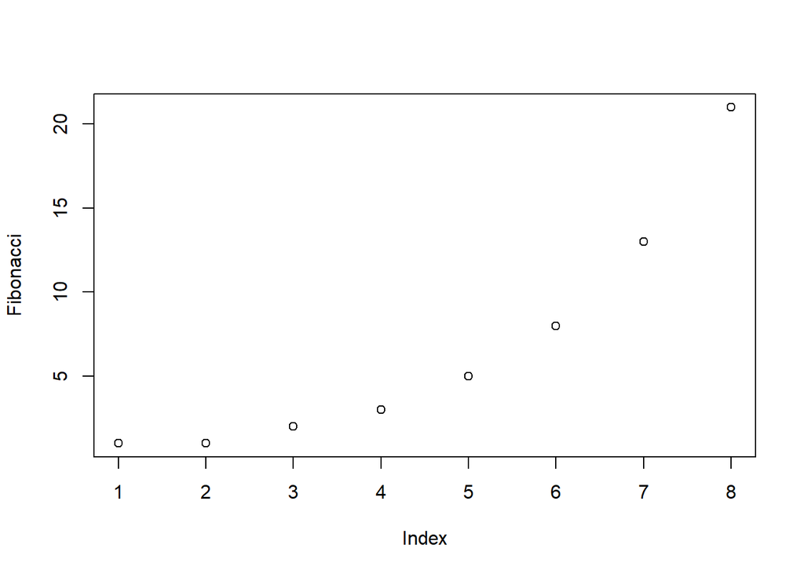

```r
Fibonacci <- c(1,1,2,3,5,8,13,21)
plot(Fibonacci)
```

The `plot()` function is a generic function like `print()` or `summary()`. Its behaviour depends on the input. In the figure above, `Fibonacci` is a vector or sequence of numbers. Then, when we run `plot(Fibonacci)`, a scatterplot is drawn where the y-axis is the values in `Fibonacci`, and the x-axis is the index or position of the values.

If you look at `help(plot)` or `?plot`, you can see that it takes two input, `x` and `y` (optional). For now, we are only doing basic plotting which is done by `plot.default()`. In `plot.default()` help page, you can see more arguments, most which are “graphical parameters”

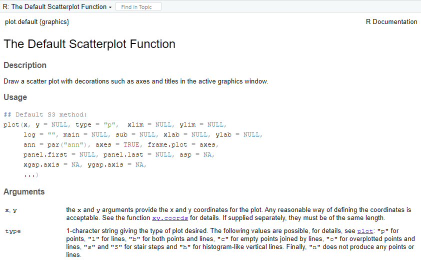

Help page for `plot()`

### Graphical parameters

So, what are “graphical parameters”? Basically, there are some characteristics/setting of a plot which are universal such as:

- colour to use for the plot
- font type/size
- plot title
- x and y axes
- and many more

In order to avoid having too many arguments for every single function, R does it by referring these as “graphical parameters”. You can check the graphical parameters using the `par()` function and its help page by running `help(par)` or `?par`. The help page for `par()` has all the listed graphical parameter and their descriptions.

You can modify the graphical parameters using the `par()` function, but we rarely do this. In most cases, we change the parameters for individual plot, instead of setting the parameters for all the plots.

### Customizing the title and axes

Here are the commonly used arguments used in the `plot()` function to modify the title and axes:

- `main`: A character string containing the title.
- `xlab` and `ylab`: A character string containing the x-axis label and y-axis label, respectively.
- `xlim` and `ylim`: A vector to specify the limit for the x-axis and y-axis.

And here are more (less commonly used) arguments for customizing the title and axes:

- `font.main`, `font.axis`, and `font.lab`: Numerical value to change the font style for plot title, axis tick marks, and axis labels. 1 is for plain text, 2 is for boldface, 3 is for italic, and 4 is for bold italic.
- `col.main`, `col.axis`, and `col.lab`: Specify colors for the plot title, axis tick marks, and axis labels. Use `colours()` to see a list of available colour names known in R. Otherwise you can specify using hex code or `rgb()` function.
- `cex.main`, `cex.axis`, and `cex.lab`: Change the font size for the plot title, axis tick marks, and axis labels. Default to 1. “cex” stands for “character expansion”
- `axes`: `axes=TRUE` if you want to draw axes. Otherwise, `axes=FALSE`.
- `xaxp` and `yaxp`: Change where the tick marks for x and y axes. It must be specified in a form `c(start, end, number_regions)`.

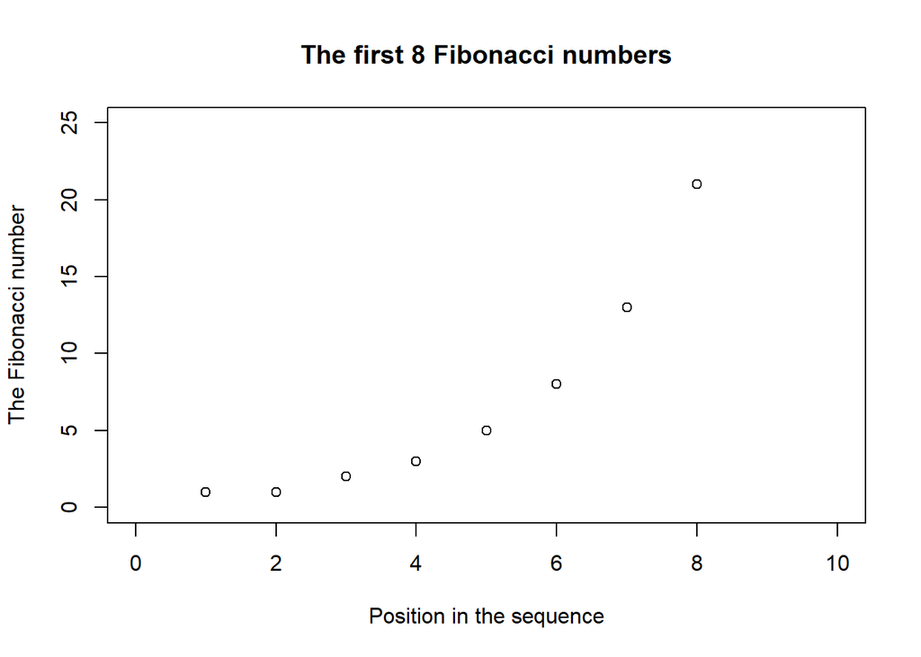

```r
plot(Fibonacci,                              # The data to plot
     main = "The first 8 Fibonacci numbers", # The title
     xlab = "Position in the sequence",      # x-axis label
     ylab = "The Fibonacci number",          # y-axis label
     xlim = c(0,10),                         # x-axis region
     ylim = c(0,25)                          # y-axis region
)
```

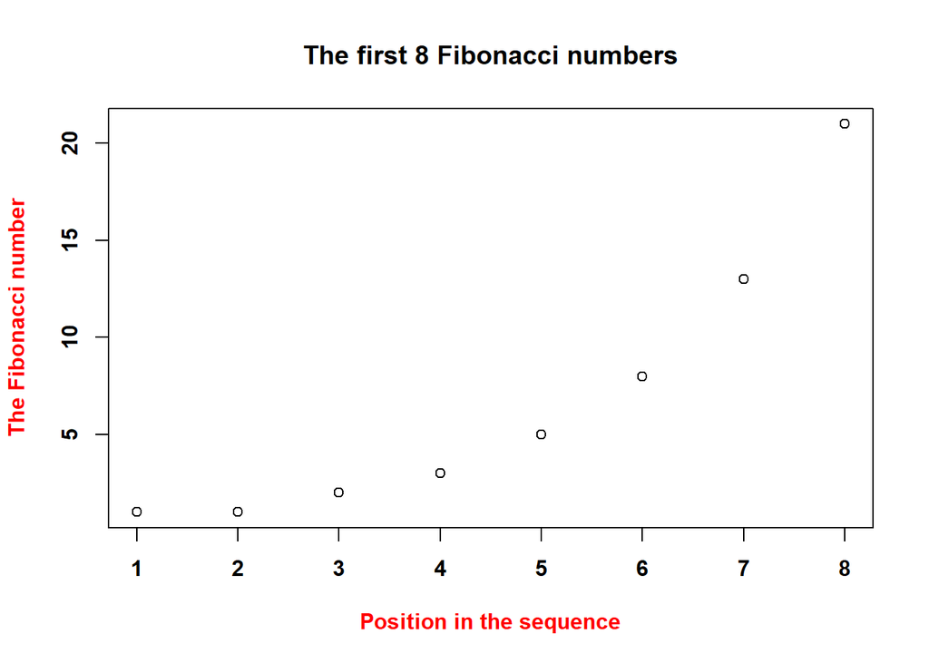

```r
plot(Fibonacci,                              # The data to plot
     main = "The first 8 Fibonacci numbers", # The title
     xlab = "Position in the sequence",      # x-axis label
     ylab = "The Fibonacci number",          # y-axis label
     font.axis = 2,                          # Bold text for numbering in axis
     font.lab = 2,                           # Bold text for labels
     col.lab = "red",                        # Red colour for labels
     yaxp = c(0, 20, 4)                      # Tickmarks for y-axis
)
```

### Changing plot types

You can also change the type of plots by changing the `type` argument:

- `type = "p"`: Draw the **p**oints only.
- `type = "l"`: Draw a **l**ine through the points. Note that it is the lower case L, not 1.
- `type = "o"`: Draw the line **o**ver the top of the points.
- `type = "b"`: Draw **b**oth points and lines, but don’t overplot.
- `type = "h"`: Draw “**h**istogram-like” vertical bars.
- `type = "s"`: Draw a **s**taircase, going horizontally then vertically.
- `type = "S"`: Draw a **S**taircase, going vertically then horizontally.
- `type = "c"`: Draw only the **c**onnecting lines from the “`b`” version.
- `type = "n"`: Draw **n**othing. Useful if you just want an empty box.

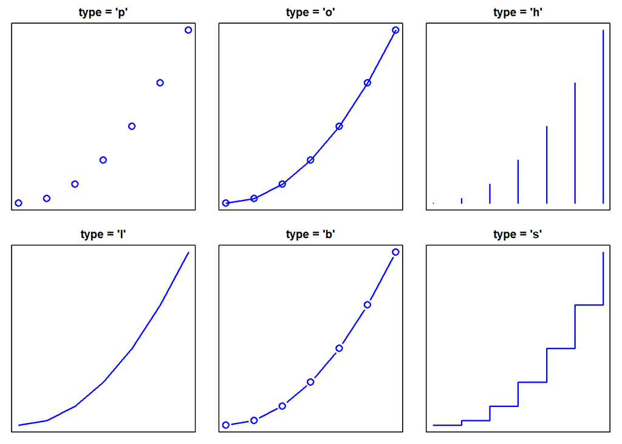

### Changing other features of the plot

Here are some additional graphical parameter that can be used to modify the plot.

- `col`: Specify the colour of the points/lines. Similar to the previous colour argument, you can use on one of `colours()` or specify using hex code or `rgb()`.
- `pch`: Specify the plot character (character used for plot points).
- `cex`: Specify the size of the plot points. Default is value 1.
- `lty`: Specify the line type.
- `lwd`: Specify the line width. Default value is 1.

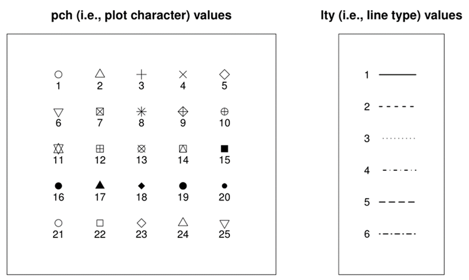

Different values for `pch` and `lty` parameter

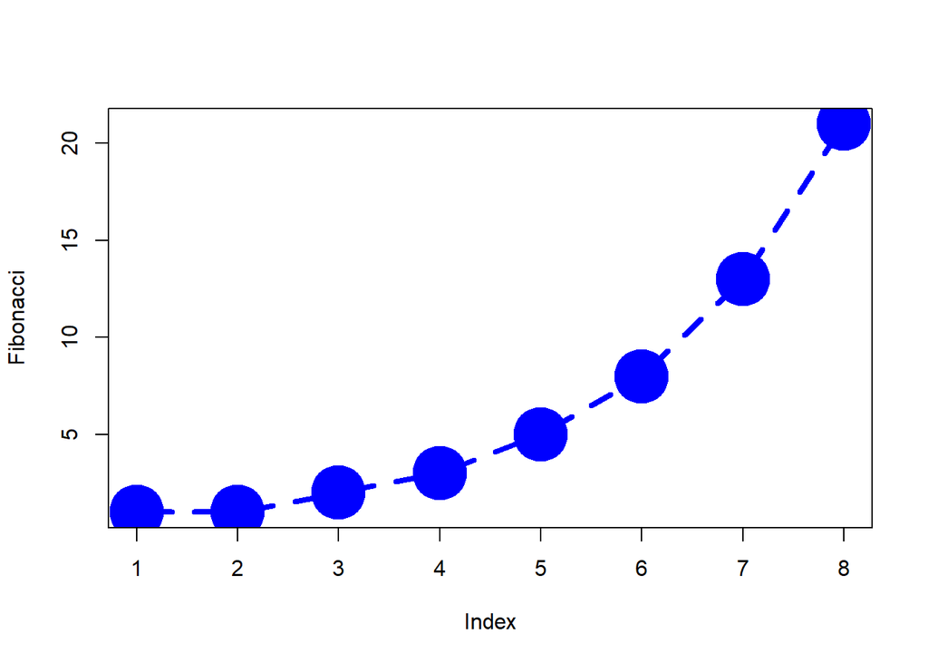

```r
plot(Fibonacci,    # The data set
     type = "b",   # Plot both points and lines
     col = "blue", # change the plot colour to blue
     pch = 19,     # Plotting character is a solid circle
     cex = 5,      # Plot the character at 5x the usual size
     lty = 2,      # Change line type to dashed
     lwd = 4       # Change line width to 4x the usual
)
```

### Adding more points/lines on an already drawn plot

If you want to add more points/lines on a plot you have drawn, you can use either `points()` or `lines()` function. The two functions are essentially the same but with different default value for `type`. You can modify the features of plotted points/lines similar to `plot()`.

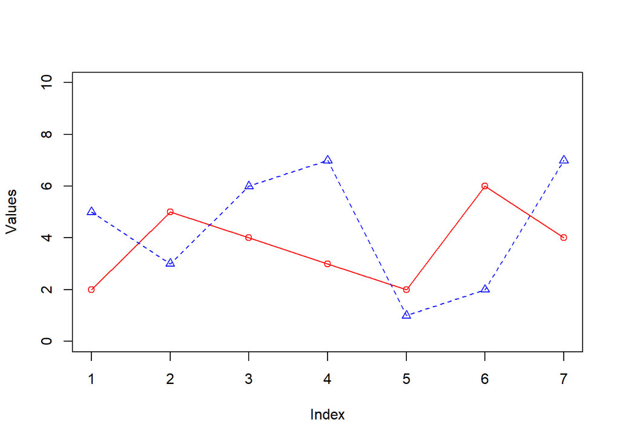

```r
x <- c(2,5,4,3,2,6,4)
y <- c(5,3,6,7,1,2,7)

# Plot for x first
plot(x, col="red", type="o", ylim=c(0,10), ylab="Values")

# Then add for y
points(y, col="blue", type="o", lty=2, pch=2)
```

### Adding legends

When you have multiple data such as in the figure above, legends should be added to describe which data is for which group. You can use `legend()` function to add legends after drawing the plot.

The important arguments are:

- `x`, `y`: The x and y position of the top left of the legend box. You can also set `x="topright"`, `"topleft"`, `"bottomright"`, or `"bottomleft"`.
- `legend`: Names to display.
- `horiz`: Set legend in column or in row. If in row, set `horiz=TRUE`.
- `text.col`: Text color.
- `inset`: To draw the legend away from x and y axis. Must be between 0 and 1.

You must also specify the line type, the plot point character, line width, colours, and other characteristics of the lines/points for the legend. You can also modify the box line type, color, etc. If there are multiple legends, use vector form to specify the legend for each lines/points.

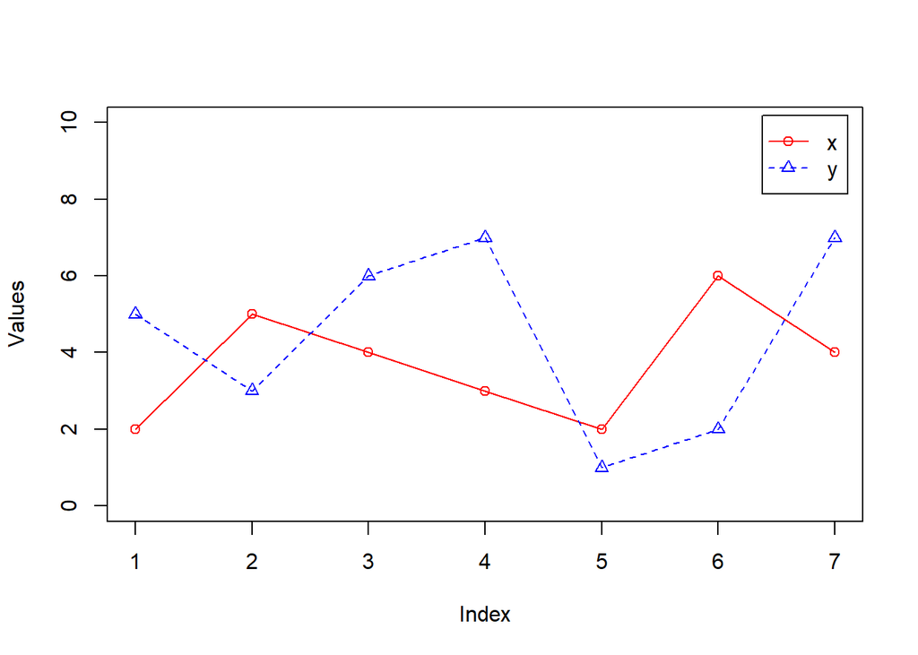

```r
# Plot the data first
plot(x, col="red", type="o", ylim=c(0,10), ylab="Values")
points(y, col="blue", type="o", lty=2, pch=2)

# Add legend
legend(x = "topright",        # Put the legends at top right
       inset = 0.02,          # Use 2% inset
       legend = c("x","y"),   # Legends for each lines/points
       col = c("red","blue"), # Colours for each lines/points
       lty = c(1,2),          # Line type for each lines/points
       pch = c(1,2),          # Point characters for each lines/points
)
```

### Other things you can add

If you want to, you can add many other things in the drawn figure. Here are some functions and their description of the things you can add.

- `text()`: Add texts to figure.
- `abline()`: Add straight lines to figure.
- `arrows()`: Add arrows to figure.
- `rect()`: Add rectangles to figure.
- `draw.circle()`: Add circles to figure. This uses the `plotrix` package.

## Commonly Drawn Figures

Now, let us look at some commonly drawn figures and their R commands.

### Plotting a function

Suppose we have a function $y=f(x)$ and we would like to draw a line representing this function. To do that, we can use the `curve()` function in R.

Here is the syntax for the function: `curve(expression, from, to, n, add, ...)`:

- `expression`: The expression of the function in terms of `x`.
- `from`, `to`: The range over which the function will be plotted.
- `n`: The number of `x` values to be evaluated. The default value is 101.
- `add`: If set to be `TRUE`, it will draw the function on existing plot. Otherwise it will create a new plot. The default is `FALSE`.

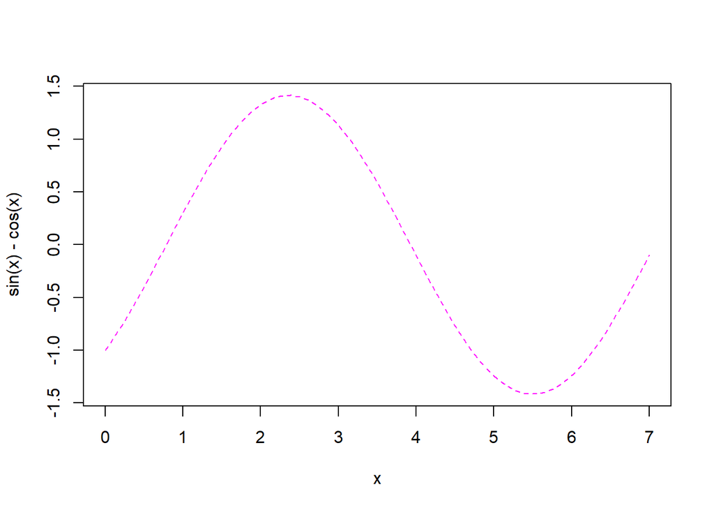

```r
curve(sin(x)-cos(x), from=0, to=7, col="magenta", lty=2)
```

Note that the previous code is equivalent to the one below.

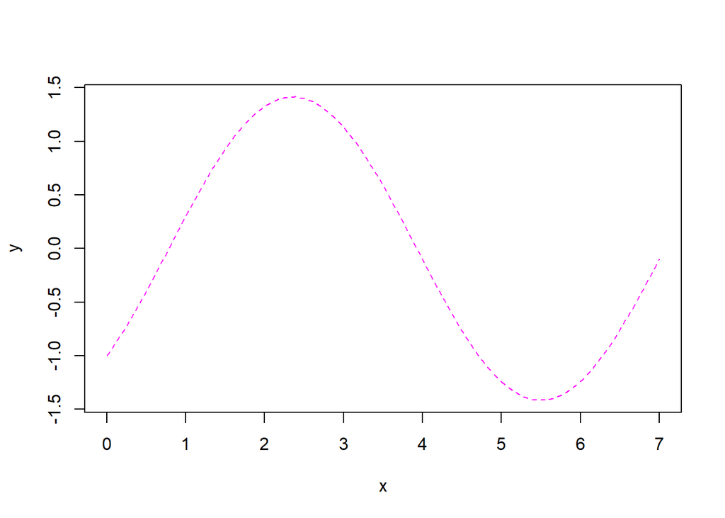

```r
x <- seq(from=0, to=7, length.out=101)
y <- sin(x)-cos(x)
plot(x, y, type='l', lty=2, col="magenta")
```

### Scatterplot

To draw a scatterplot, simply use `plot()` function with `x` and `y` arguments.

```r
# Setting up the data
Student<-c(1,2,3,4,5,6,7,8,9,10)
Score<-c(100,95,92,90,85,80,78,75,72,65)
IQ<-c(125,104,110,105,100,100,95,95,85,90)
StudyHours<-c(30,40,25,20,20,20,15,10,0,5)
GPA<-c(3.9,2.6,2.7,3,2.4,2.2,2.1,2.1,1.5,1.8)
Class<-c("A","B","A","A","B","B","A","B","B","A")
TestScore <- data.frame(Student,Score,IQ,StudyHours,GPA,Class)
```

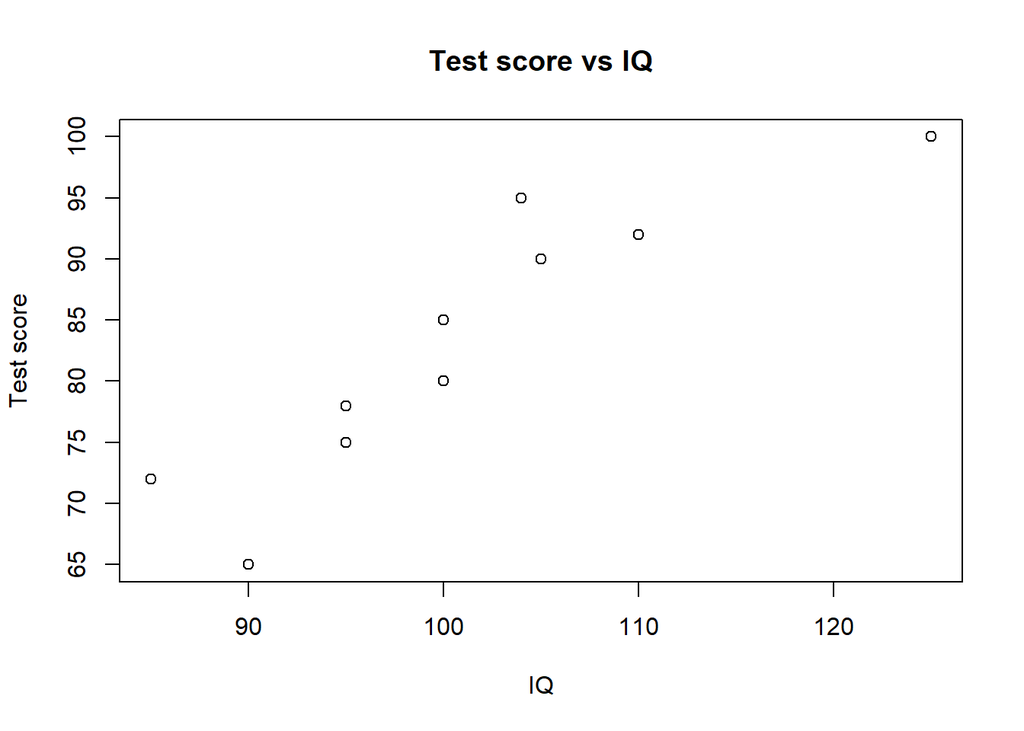

```r
plot(x = TestScore$IQ, y = TestScore$Score,
     main = "Test score vs IQ",
     xlab="IQ", ylab="Test score"
)
```

An alternative way to write the code is by using `formula` class object for the argument. Formula object is a variable that specifies a relationship between other variables. In the code below, we write down `Score~IQ`for the `formula`, which can be interpreted as `Score` *depends on* `IQ`.

Note also that in the code below, the `data` argument is specified which is the data frame at which the variables `Score` and `IQ` are from. The code before does not use the `data` argument as we call the variables directly using `TestScore$Score` and `TestScore$IQ`.

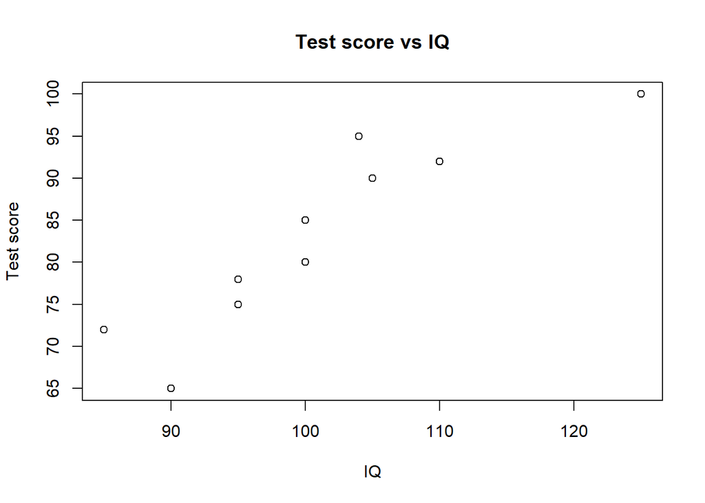

```r
plot(Score~IQ, data=TestScore,
     main="Test score vs IQ",
     xlab="IQ", ylab="Test score"
)
```

### Scatterplot matrix

To draw a scatterplot matrix, use the `pairs()` function.

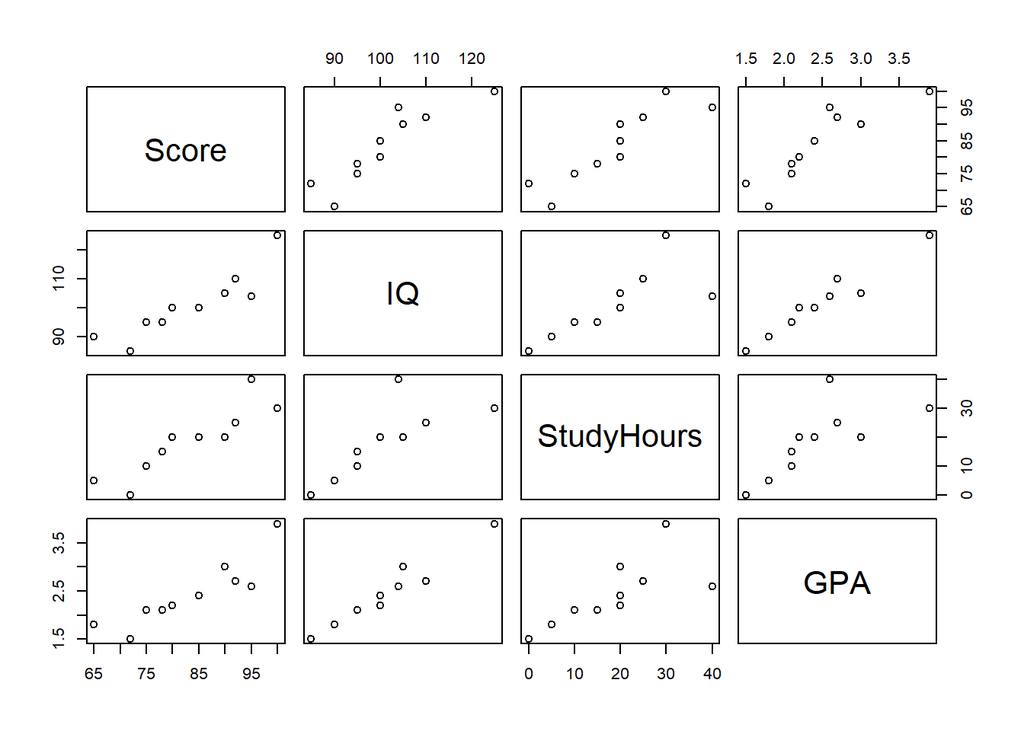

```r
pairs(~Score+IQ+StudyHours+GPA, data=TestScore)
```

### Histogram

To draw a histogram, use `hist()` function.

Here is the syntax for the function: `hist(x, breaks, freq, ...)`

- `x`: a vector of values for which the histogram is desired.
- `breaks`: how many “breaks” you want the histogram to bin the data. There are few ways to specify this argument:
  - a single number giving the number of bins for the histogram.
  - a vector giving the breakpoints between bins
  - a character string naming an algorithm to compute the number of bins.
- `freq`: `freq=TRUE` if you want the y-axis to be the frequency for each bin. `freq=FALSE` if you want the y-axis to be the relative frequency or probability for each bin.

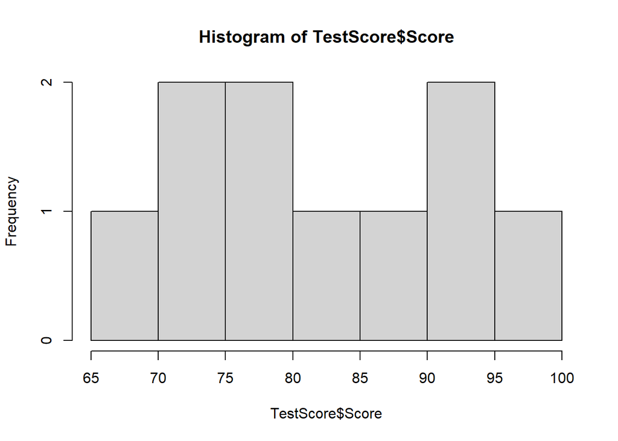

```r
hist(TestScore$Score)
```

### Boxplot

You can use `boxplot()` to draw the boxplot, also called the box-and-whisker plot.

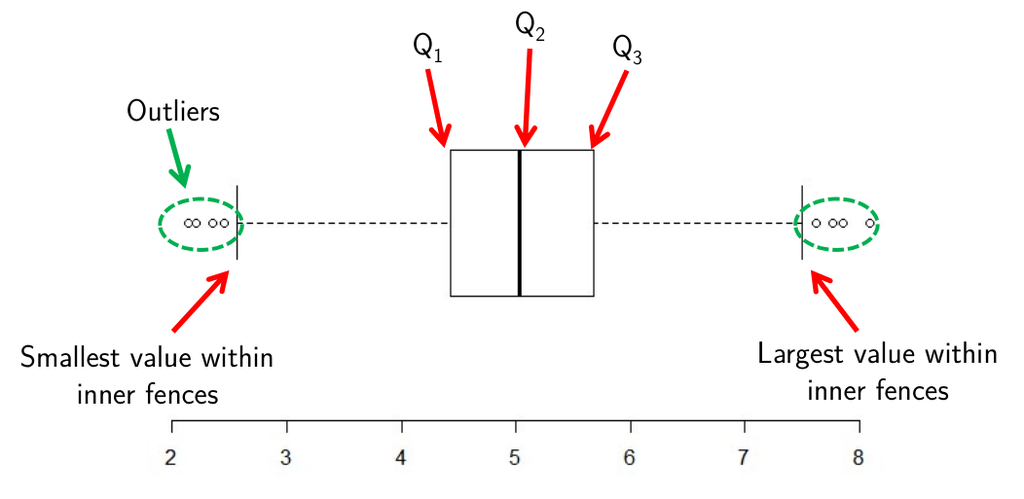

Diagram of a boxplot

The boxplot is a graph used to show the distribution of data. In the figure above, Q<sub>1</sub>, Q<sub>2</sub>, and Q<sub>3</sub> are the three quartiles representing the position of values at the 25%, 50%, and 75% of the data, respectively. It can also be used to detect outliers.

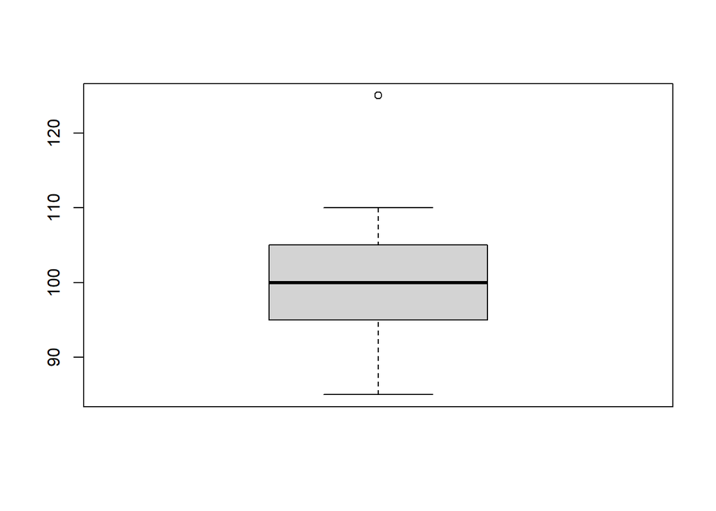

```r
boxplot(TestScore$IQ)
```

Note that you can use the argument `horizontal=TRUE` if you want the boxplot to be horizontal.

### Side-by-side boxplot

You can draw multiple boxplots in the same figure using the `formula` class object in the `boxplot()` function.

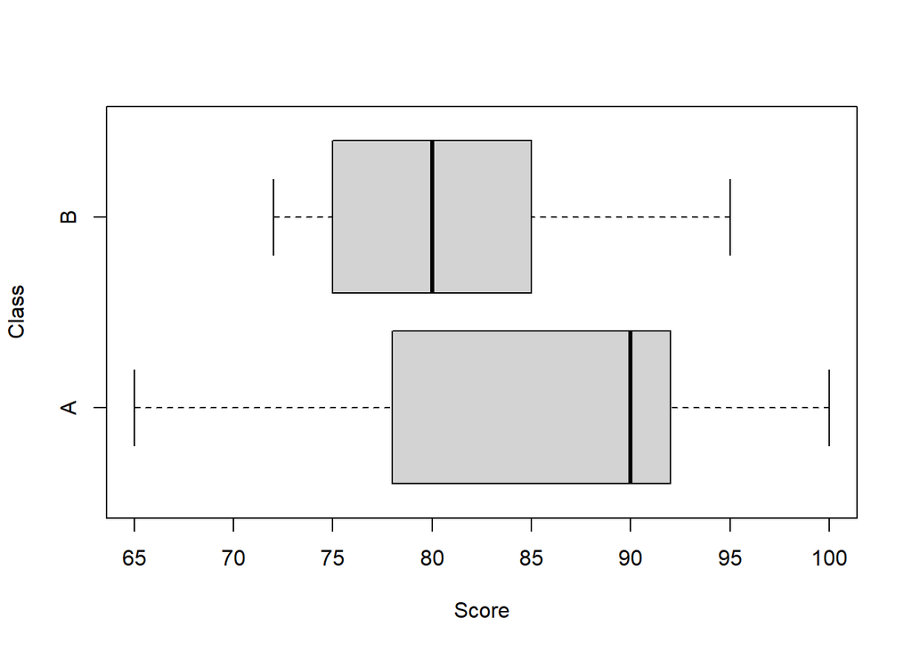

```r
boxplot(Score~Class, data=TestScore, horizontal=TRUE)
```

Alternatively, specifying more than one vector will draw a side- by-side boxplot.

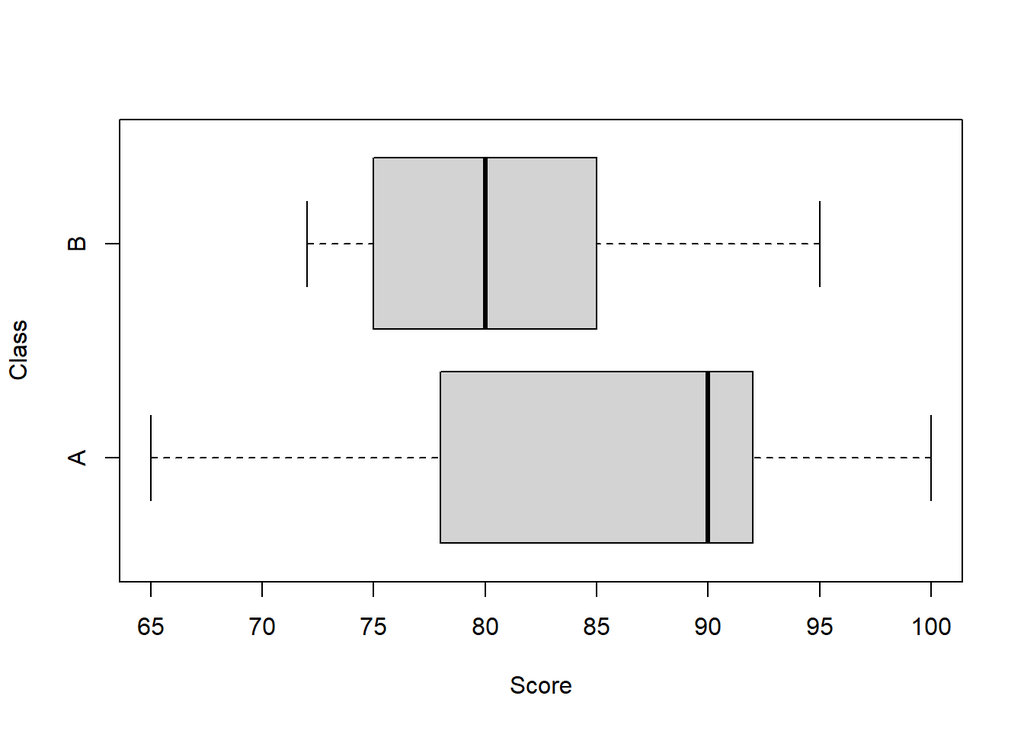

```r
library(dplyr)
ScoreA = filter(TestScore,Class=="A")$Score
ScoreB = filter(TestScore,Class=="B")$Score
boxplot(ScoreA, ScoreB, names = c("A","B"),
        horizontal=TRUE, xlab="Score", ylab="Class")
```

### Bar graph

To draw a bar graph, chart, or plot, we can use the `barplot()` function.

Here is the syntax for the function: `barplot(height, names.arg, ...)`

- `height`: the height for each bar.
- `names.arg`: a vector of names for each bar.

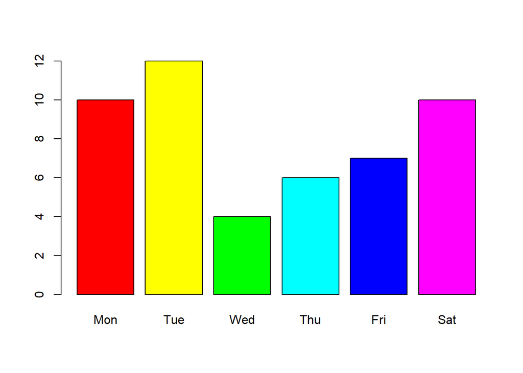

```r
data <- c(10,12,4,6,7,10)
barplot(height=data,
        names.arg=c("Mon","Tue","Wed","Thu","Fri","Sat"),
        col=rainbow(6)
)
```

### Pie chart

You can also draw a pie chart using the `pie()` function.

Here is the syntax for the function: `pie(x, labels, ...)`

- `x`: a vector of non-negative numerical quantities. The values in `x` are displayed as the areas of pie slices.
- `labels`: the labels for each pie slice.

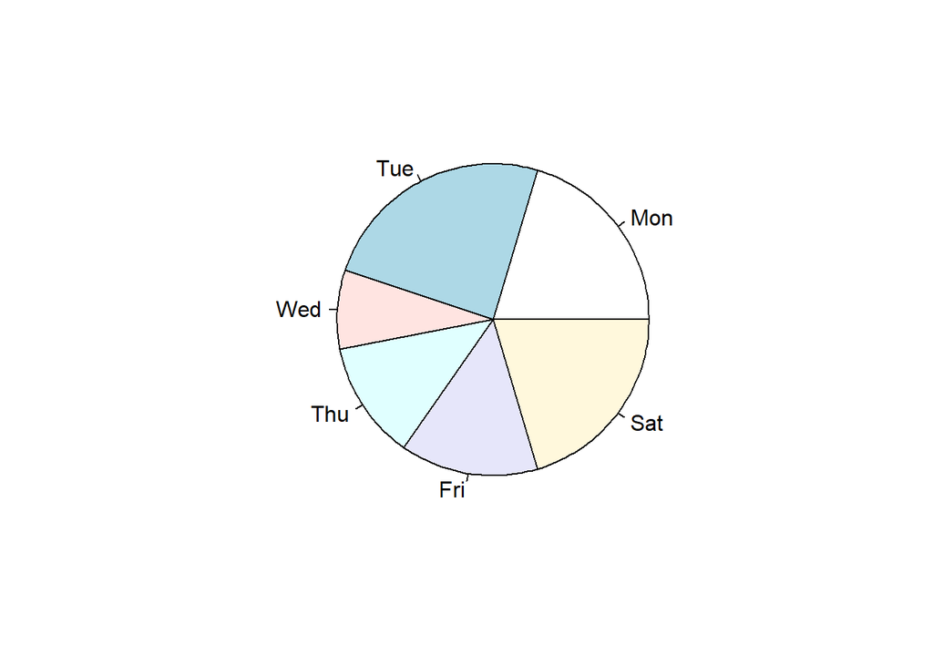

```r
data <- c(10,12,4,6,7,10)
pie(x=data, labels=c("Mon","Tue","Wed","Thu","Fri","Sat"))
```

## A Few Additional Notes

### Saving image

Saving images using RStudio is easy. Just click the export button and select the desired output file.

To save a drawn figure in RStudio using menus, go to the *Plots* tab and click *Export*. From there you have the option to *Save as Image* or *Save as PDF*. Then, you have the option to specify the size of the image you want to save.

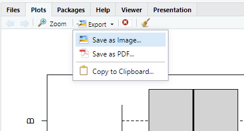

Click the *Export* button to save image

When choosing to *Save as Image*, you would have a few options for the image format. The table below shows all the possible image format that you can save to.

| Image Format | File Extension |
| --- | --- |
| Portable Document Format | .pdf |
| Portable Network Graphics | .png |
| JPEG | .jpeg |
| Tagged Image File Format | .tiff |
| Bitmap | .bmp |
| Enhanced Metafile | .emf |
| Scalable Vector Graphics | .svg |
| Encapsulated PostScript | .eps |

The PDF, EMF, SVG, and EPS formats are vector formats where images are stored as equations. This leads them to be scalable without the loss of quality if you enlarge or reduce its image size. On the other hand, PMG, JPEG, TIFF, and BMP formats are raster formats where images are stored as grid of pixels, making them lose quality if you enlarge or reduce the image size.

If you are planning to use the image into a report in Microsoft Word or PowerPoint, it is recommended to use the EMF or SVG format. If you plan to put the image on a website, you might want to use PNG format. And if you plan to edit the image with other software such as Adobe Illustrator, you can save the image in the PDF or SVG format.

You can also save images using codes in R but it is kind of complicated. The function `dev.print()` can be used if you want to save the images using the console.

```r
boxplot(Score~Class, data=TestScore)

dev.print(device = png,              # What are we printing to?
          filename = "boxplot.png",  # Name of the image file
          width = 4,                 # How wide should it be
          height = 3,                # How high should it be
          units = "in",              # What the units are
          res = 300                  # The resolution or dpi
          )
dev.off()                            # Shuts down the device
```

### Specifying diagram dimension

By default, when you create a figure in RStudio, the figure will appear on the *Plots* tab. However, you can create a new window for the diagram by using `dev.new()` function and specify the dimension you want the diagram to be in. This can be useful for functions that depends on the dimension of the diagram window for example `legend()`.

```r
dev.new(width=6, height=5, unit="in", noRStudioGD=TRUE)
```

### Multiple plots in the same figure

In some cases, you may want to include several plots in the same figure. You can do this by using the `layout()` function. The `layout()` function sets the layout of the figure. It takes argument in the form of matrix.

In the code below, we use the following matrix as the layout. Figure 1 will be placed at the position 1 in the matrix, and so on.

$$\begin{bmatrix}
1 & 1 \\
2 & 3
\end{bmatrix}$$

Additionally, we may need to reset the layout after producing the figure so that the next time we want to plot graphs, it does not used the modified layout.

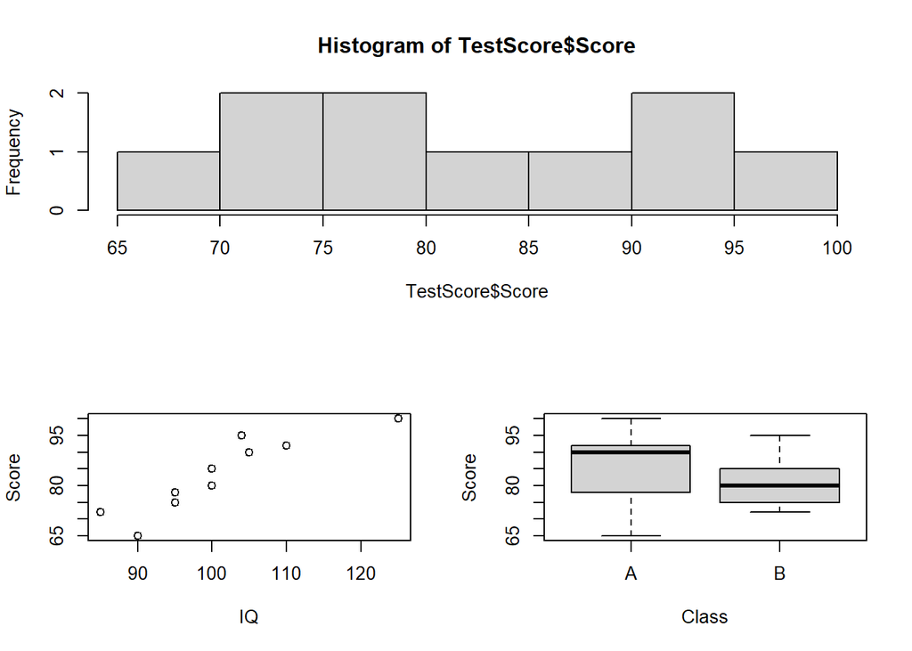

```r
layout(matrix(c(1,1,2,3),nrow=2,byrow=TRUE)) # Set the layout
hist(TestScore$Score)                        # First plot
plot(Score~IQ, data=TestScore)               # Second plot
boxplot(Score~Class, data=TestScore)         # Third plot
layout(1)                                    # Reset layout
```

Alternatively, you can change the `mfrow` or `mfcol` graphical parameter. Running `par(mfrow = c(a,b))` will give a a-by-b matrix-like figure. In the code below, we set the layout to be a 1 row by 2 columns matrix.

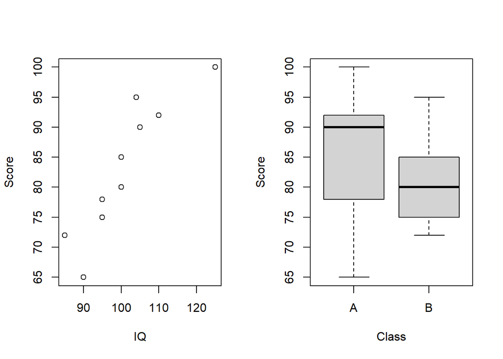

```r
par(mfrow = c(1,2))                  # Set the layout
plot(Score~IQ, data=TestScore)       # First plot
boxplot(Score~Class, data=TestScore) # second plot
par(mfrow = c(1,1))                  # reset layout
```

## Conclusion

This topic discusses about using base R to produce visuals and plots without additional packages. We have also talked about how to use the `plot()` function, graphical parameters, customizing plots and others. We have also shown how to use base R to produce commonly drawn plots. This topic uses base R but in the next topic, we will be using ggplot2 to produce visuals and plots, which to many, is better and nicer than base R.